# Hands-on session 4: Cell Type-level Analysis in R

Ángeles Arzalluz-Luque

2023-09-22

# Contents

## 0.1 Introduction

In this session, we will perform a series of analyses that can be performed on already-clustered single-cell data, including:

- Assignment of cell labels using a reference dataset.
- Identification of marker genes for clusters for *de novo* cell label assignment.
- Differential expression analysis.
- Differential abundance analysis.

This tutorial is based on the following resources:

- [Azimuth tutorial](https://satijalab.github.io/azimuth/articles/run_azimuth_tutorial.html)
- “Orchestrating single-cell analysis with Bioconductor” book chapters:
  - [Marker gene detection](https://bioconductor.org/books/3.17/OSCA.basic/marker-detection.html)
  - [Cell type annotation](https://bioconductor.org/books/3.17/OSCA.basic/cell-type-annotation.html)
- [Seurat Differential Expression testing vignette](https://satijalab.org/seurat/articles/de_vignette)
- [Milo demo vignette](https://bioconductor.org/packages/release/bioc/vignettes/miloR/inst/doc/milo_demo.html)

## 0.2 Required packages

We will first load a series of single-cell analysis R packages:

```r
library(Seurat)
library(SeuratData)
library(SeuratDisk)
library(SingleCellExperiment)
library(Azimuth)
library(scran)
library(scater)
library(miloR)
```

## 0.3 Data

All data and data-related files for this hands-on session will be available under the following directory:

```r
data_dir <- c("HandsOn4_CellType_Analysis/")
```

We will append this prefix to all the paths in the tutorial.

For this hands-on session, we will use the `SeuratObject` obtained after running all the analysis in hands-on session 3, stored as an H5Seurat file:

```r
setty_seurat <- LoadH5Seurat("../HandsOn3_SingleCell_Data_QC/processed_data/setty_seurat_clustered.h5seurat")
```

```
## Validating h5Seurat file
```

```
## Initializing RNA with data
```

```
## Adding counts for RNA
```

```
## Adding scale.data for RNA
```

```
## Adding feature-level metadata for RNA
```

```
## Adding variable feature information for RNA
```

```
## Adding miscellaneous information for RNA
```

```
## Adding reduction pca
```

```
## Adding cell embeddings for pca
```

```
## Adding feature loadings for pca
```

```
## Adding miscellaneous information for pca
```

```
## Adding reduction tsne
```

```
## Adding cell embeddings for tsne
```

```
## Adding miscellaneous information for tsne
```

```
## Adding graph RNA_nn
```

```
## Adding graph RNA_snn
```

```
## Adding command information
```

```
## Adding cell-level metadata
```

```
## Adding miscellaneous information
```

```
## Adding tool-specific results
```

## 0.4 Assignment of cell labels using a reference dataset.

After clustering cells, it might be difficult (or even risky) to assign cell identities blindly. When well-curated references are available, cells can be confidently and rapidly annotated by mapping to already-characterized cell atlases.

The `Azimuth` R package provides not only functions, but also integrated references for multiple human tissues, including bone marrow. These are installed via the `SeuratData` package, which contains the following references:

```r
available_data <- AvailableData()
available_data[grep("Azimuth", available_data[, 3]), 1:3]
```

```
##                                  Dataset Version                        Summary
## adiposeref.SeuratData         adiposeref   1.0.0     Azimuth Reference: adipose
## bonemarrowref.SeuratData   bonemarrowref   1.0.0  Azimuth Reference: bonemarrow
## fetusref.SeuratData             fetusref   1.0.0       Azimuth Reference: fetus
## heartref.SeuratData             heartref   1.0.0       Azimuth Reference: heart
## humancortexref.SeuratData humancortexref   1.0.0 Azimuth Reference: humancortex
## kidneyref.SeuratData           kidneyref   1.0.1      Azimuth Reference: kidney
## lungref.SeuratData               lungref   2.0.0        Azimuth Reference: lung
## mousecortexref.SeuratData mousecortexref   1.0.0 Azimuth Reference: mousecortex
## pancreasref.SeuratData       pancreasref   1.0.0    Azimuth Reference: pancreas
## pbmcref.SeuratData               pbmcref   1.0.0        Azimuth Reference: pbmc
## tonsilref.SeuratData           tonsilref   1.0.0      Azimuth Reference: tonsil
```

We will use the `bonemarrowref` reference, but first we need to install and load the `SeuratData` package containing the bone marrow reference dataset using the source package that was previously downloaded:

```r
if(!"bonemarrowref.SeuratData" %in% installed.packages()[,"Package"]){
  install.packages("bonemarrowref.SeuratData_1.0.0.tar.gz",
                 repos = NULL, type = "source")
}

library(bonemarrowref.SeuratData)
```

To annotate cell types, we will use the `RunAzimuth()` function, which can take a `SeuratObject` as input and returns the same type of object including cell type annotations:

```r
setty_seurat <- RunAzimuth(query = setty_seurat,
                           reference = "bonemarrowref")
```

```
## An AzimuthData object - reference version: 1.0.0
## Contains 2 meta.data field(s) to transfer.
```

```
## detected inputs from HUMAN with id type Gene.name
```

```
## reference rownames detected HUMAN with id type Gene.name
```

```
## Using reference SCTModel to calculate pearson residuals
```

```
## Determine variable features
```

```
## Setting min_variance to:  -Inf
```

```
## Calculating residuals of type pearson for 2749 genes
```

```
## Set default assay to refAssay
```

```
## Normalizing query using reference SCT model
```

```
## Projecting cell embeddings
```

```
## Finding query neighbors
```

```
## Finding neighborhoods
```

```
## Finding anchors
```

```
##  Found 3234 anchors
```

```
## Finding integration vectors
```

```
## Finding integration vector weights
```

```
## Predicting cell labels
## Predicting cell labels
```

```
##
## Integrating dataset 2 with reference dataset
```

```
## Finding integration vectors
```

```
## Integrating data
```

```
## Running UMAP projection
```

```
## 13:55:39 Processing block 1 of 1
```

[output not shown]

Let’s explore the `RunAzimuth()` results:

```r
table(setty_seurat$predicted.celltype.l1)
```

```
##
## CD4 T    DC  HSPC  Mono
##     7    26  2942     8
```

```r
table(setty_seurat$predicted.celltype.l2)
```

```
##
##         BaEoMa      CD14 Mono      CD4 Naive            CLP    Early Eryth
##             87              8             26            301            398
##            EMP            GMP            HSC     Late Eryth           LMPP
##            182            477            432             39            500
##       Memory B            pDC          pre B        pre-mDC        pre-pDC
##              1             27            337              2             49
##          pro B        Prog Mk transitional B
##             73             38              6
```

As you can see, the method provides cell type labels at two levels of hierarchy: - There are four broad cell types, although most cells are classified as Hematopoietic Stem and Progenitor Cells (HSPCs). - There are several sub-cell types within them, including different stages of cell differentiation and lineages.

Let’s visualize these results using tSNE:

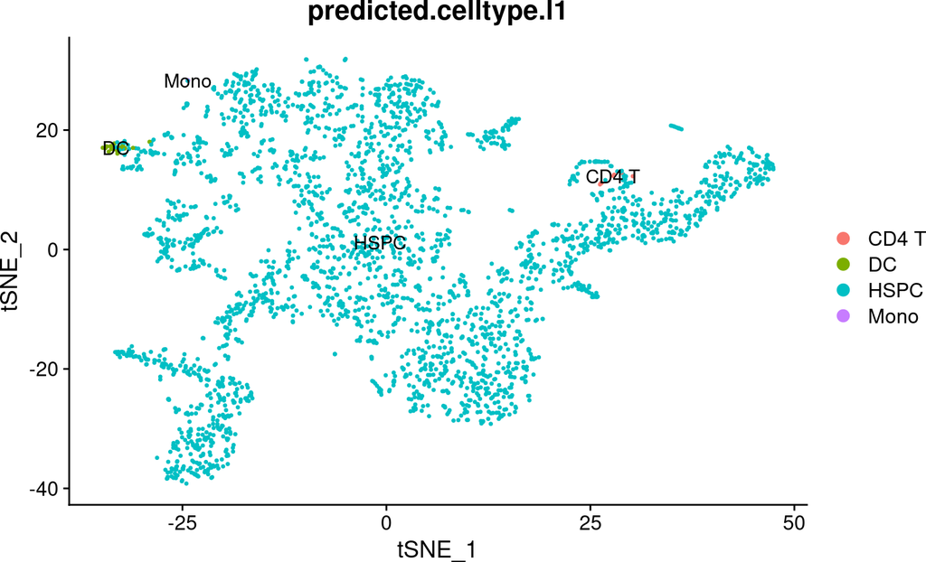

```r
DimPlot(setty_seurat, group.by = "predicted.celltype.l1",
        reduction = "tsne", label = TRUE)
```

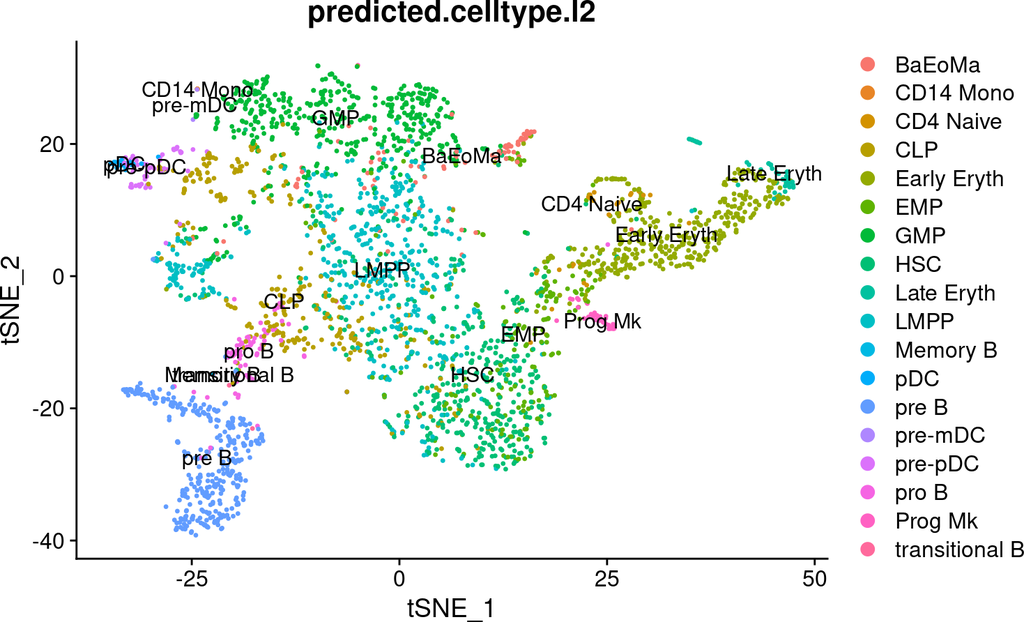

```r
DimPlot(setty_seurat, group.by = "predicted.celltype.l2",
        reduction = "tsne", label = TRUE)
```

## 0.5 Assignment of cell labels *de novo* using marker genes

Strategies for cell labelling are often based on the definition of **marker genes**, i.e. genes that are highly expressed in each cell type. This is useful when only the identities of the markers are available.

First, to find the genes that are significantly highly expressed in each cell type, we will use the `scoreMarkers()` function from the `scran` R package. This function compares each pair of clusters and computes scores quantifying the differences in the expression distributions between clusters.

Importantly, `scran` belongs to the family of R packages that are based on the `SingleCellExperiment` data class, so we will need to transform our `SeuratObject` and correctly fill the slots with the normalized and log-transformed counts:

```r
setty_sce <- as.SingleCellExperiment(setty_seurat)
colLabels(setty_sce) <- setty_sce$ident
normcounts(setty_sce) <- setty_seurat[["RNA"]]@data
logcounts(setty_sce) <- log2(normcounts(setty_sce)+1)

table(setty_sce$predicted.celltype.l2)
```

```
##
##         BaEoMa      CD14 Mono      CD4 Naive            CLP    Early Eryth
##             87              8             26            301            398
##            EMP            GMP            HSC     Late Eryth           LMPP
##            182            477            432             39            500
##       Memory B            pDC          pre B        pre-mDC        pre-pDC
##              1             27            337              2             49
##          pro B        Prog Mk transitional B
##             73             38              6
```

Now, we will apply the `scoreMarkers()` function. We will define a minimum log fold-change of 1 to consider a gene as relevant to prevent small changes to drive the detected markers:

```r
markers <- scoreMarkers(setty_sce,
                        groups = colLabels(setty_sce),
                        lfc = 1)

colnames(markers[[1]])
```

```
##  [1] "self.average"          "other.average"         "self.detected"
##  [4] "other.detected"        "mean.logFC.cohen"      "min.logFC.cohen"
##  [7] "median.logFC.cohen"    "max.logFC.cohen"       "rank.logFC.cohen"
## [10] "mean.AUC"              "min.AUC"               "median.AUC"
## [13] "max.AUC"               "rank.AUC"              "mean.logFC.detected"
## [16] "min.logFC.detected"    "median.logFC.detected" "max.logFC.detected"
## [19] "rank.logFC.detected"
```

The `markers` list contains one table per cluster including the marker scores for each gene in that cluster. Since this is a very long list, and not all genes will be relevant, we need to select one of these variables to **rank markers** and subset the list.

A good metric to do this is **Area Under the Curve (AUC)**, which measures our ability to distinguish between two distributions in a pairwise comparison. The AUC represents the probability that a randomly chosen observation from our cluster of interest is greater than a randomly chosen observation from the other cluster. A value of 1 corresponds to upregulation, where all values of our cluster of interest are greater than any value from the other cluster; a value of 0.5 means that there is no net difference in the location of the distributions; and a value of 0 corresponds to downregulation.

Let’s focus on **cluster 2**, and select the top 100 genes with the largest mean AUC:

```r
selected_cluster <- "2"

markers_select <- markers[[selected_cluster]]

top_markers <- order(markers_select$mean.AUC,
                     decreasing = TRUE)[1:100]

markers_select[top_markers,1:4]
```

```
## DataFrame with 100 rows and 4 columns
##         self.average other.average self.detected other.detected
##            <numeric>     <numeric>     <numeric>      <numeric>
## XACT         1.50020      0.366477      0.870558       0.239235
## ZNF385D      1.62307      0.439914      0.934010       0.305608
## CRACD        1.37373      0.502795      0.931472       0.396033
## ST8SIA6      1.22997      0.458414      0.888325       0.359689
## PDZD8        1.20864      0.480953      0.855330       0.392649
## ...              ...           ...           ...            ...
## STK4        0.741428      0.414922      0.631980       0.362221
## ARMC8       0.715627      0.348222      0.644670       0.314757
## MCTP2       1.064175      0.751001      0.822335       0.585302
## LDLRAD4     0.967820      0.736086      0.725888       0.551837
## SLC24A3     0.638927      0.334299      0.479695       0.244840
```

Let’s plot the top markers in the cluster using the `plotExpression()` function in the `scater` QC R package:

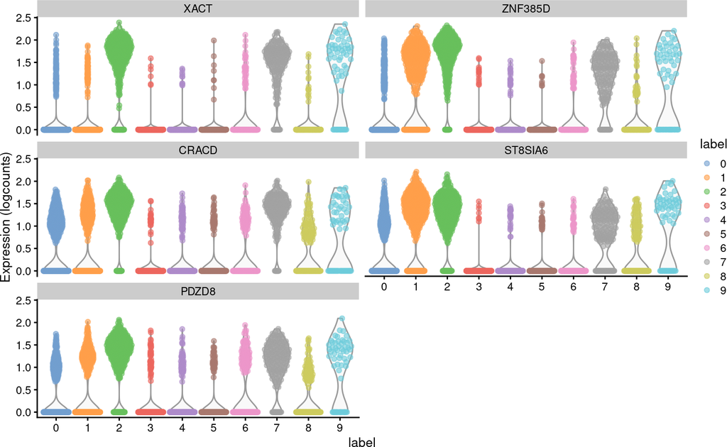

```r
plotExpression(setty_sce,
               features = c("XACT", "ZNF385D", "CRACD",
                            "ST8SIA6", "PDZD8"),
               x = "label", colour_by = "label")
```

While this is very interesting, gene names may not mean anything by themselves. To better interpret the **list of markers for cluster 2**, we will test these genes for enrichment of gene sets in the Gene Ontology (GO). Doing this, we will get a sense of the biological processes that are active in each cell type, which can give us clues regarding cell type identities.

There are many ways to do this, but in this case, we will use the `limma` R package and the `goana()` function, which performs a hypergeometric test to identify GO terms that are overrepresented in our marker subset.

Since some of our gene IDs are in ENSEMBL format and others are gene symbols, and this function requires them to be Entrez IDs, we will map the identifiers to obtain the Entrez equivalents using the genome-wide human annotation:

```r
library(org.Hs.eg.db)
```

```r
# map gene IDs to database
entrez_ids_ens <- mapIds(org.Hs.eg.db,
                     keys = rownames(markers_select),
                     column = "ENTREZID", keytype = "ENSEMBL")
entrez_ids_symb <- mapIds(org.Hs.eg.db,
                     keys = rownames(markers_select),
                     column = "ENTREZID", keytype = "SYMBOL")
# merge
entrez_ids_symb[is.na(entrez_ids_symb)] <- entrez_ids_ens[is.na(entrez_ids_symb)]
```

Now, we can run the `goana()` enrichment analysis on our top markers vs all markers:

```r
library(limma)

go_out <- goana(entrez_ids_symb[top_markers],
                species = "Hs",
                universe = entrez_ids_symb)

# Only keeping biological process terms that are not overly general
go_out <- go_out[order(go_out$P.DE),]
go_useful <- go_out[go_out$Ont=="BP" & go_out$N <= 150,]
head(go_useful[,c(1,3,4)], 40)
```

```
##                                                                               Term
## GO:0060216                                                  definitive hemopoiesis
## GO:0035162                                                   embryonic hemopoiesis
## GO:1990079                                                   cartilage homeostasis
## GO:0046928                                regulation of neurotransmitter secretion
## GO:0042304                           regulation of fatty acid biosynthetic process
## GO:0045638                     negative regulation of myeloid cell differentiation
## GO:0006787                         porphyrin-containing compound catabolic process
## GO:0033015                                          tetrapyrrole catabolic process
## GO:0042168                                                  heme metabolic process
## GO:0051588                                regulation of neurotransmitter transport
## GO:0060215                                                   primitive hemopoiesis
## GO:1904753 negative regulation of vascular associated smooth muscle cell migration
## GO:0006778                         porphyrin-containing compound metabolic process
## GO:2000300                               regulation of synaptic vesicle exocytosis
## GO:2000480           negative regulation of cAMP-dependent protein kinase activity
## GO:0071901         negative regulation of protein serine/threonine kinase activity
## GO:1904705      regulation of vascular associated smooth muscle cell proliferation
## GO:0007229                                     integrin-mediated signaling pathway
## GO:0015918                                                        sterol transport
## GO:1990874                    vascular associated smooth muscle cell proliferation
## GO:0032310                                                 prostaglandin secretion
## GO:0033013                                          tetrapyrrole metabolic process
## GO:0006879                                      intracellular iron ion homeostasis
## GO:1903305                               regulation of regulated secretory pathway
## GO:0030219                                           megakaryocyte differentiation
## GO:0045723                  positive regulation of fatty acid biosynthetic process
## GO:0001837                                    epithelial to mesenchymal transition
## GO:0006633                                         fatty acid biosynthetic process
## GO:0034755                                        iron ion transmembrane transport
## GO:0042440                                               pigment metabolic process
## GO:0007269                                              neurotransmitter secretion
## GO:0099643                                             signal release from synapse
## GO:0030011                                            maintenance of cell polarity
## GO:1904752          regulation of vascular associated smooth muscle cell migration
## GO:2000479                    regulation of cAMP-dependent protein kinase activity
## GO:0050995                          negative regulation of lipid catabolic process
## GO:1904738                        vascular associated smooth muscle cell migration
## GO:0035855                                               megakaryocyte development
## GO:0070527                                                    platelet aggregation
```

[output cut: 27 more lines]

```
## GO:0045723  15  2
## GO:0001837 118  4
## GO:0006633 120  4
## GO:0034755  16  2
## GO:0042440  58  3
## GO:0007269 124  4
## GO:0099643 124  4
## GO:0030011  17  2
## GO:1904752  17  2
## GO:2000479  18  2
## GO:0050995  19  2
## GO:1904738  19  2
## GO:0035855  19  2
## GO:0070527  65  3
## GO:0019217  66  3
```

If we check the [GO database](https://geneontology.org/) for the most enriched term, “definitive hemopoiesis”, we find that this corresponds to an intermediate state in erythrocyte differentiation. While other terms point to earlier stages in blood cell differentiation, such as “embryonic hemopoiesis” and “negative regulation of myeloid cell differentiation”, terms such as “heme metabolic process” and “tetrapyrrole catabolic process” and “intracellular iron ion homeostasis” point to hemoglobin metabolism, suggesting that these cells are **erythrocytes or late-stage erythrocyte precursors**. If you go back to the Azimuth cell type annotation results, you see that this cluster is in fact labelled as **early erythrocytes**.

## 0.6 Differential Expression analysis

Even though marker gene detection is based on approaches that are similar to those for Differential Expression (DE) analysis, we may want to obtain more detailed results regarding the DE genes between two specific clusters. To achieve this, we will use the `SeuratObject` and the Azimuth cell type identity results.

The bulk of Seurat’s differential expression features can be accessed through the `FindMarkers()` function. To test for differential expression between two specific groups of cells, we will specify the `ident.1` and `ident.2` parameters. Let’s perform a DE analysis comparing Common Lymphoid Progenitor (CLP) cells to a more differentiated stage, pre-B cells:

```r
table(setty_seurat$predicted.celltype.l2)
```

```
##
##         BaEoMa      CD14 Mono      CD4 Naive            CLP    Early Eryth
##             87              8             26            301            398
##            EMP            GMP            HSC     Late Eryth           LMPP
##            182            477            432             39            500
##       Memory B            pDC          pre B        pre-mDC        pre-pDC
##              1             27            337              2             49
##          pro B        Prog Mk transitional B
##             73             38              6
```

```r
preB_markers <- FindMarkers(setty_seurat,
                                     group.by = "predicted.celltype.l2",
                                     ident.1 = "pre B",
                                     ident.2 = "CLP",
                                     logfc.threshold = 1)

head(preB_markers, 10)
```

```
##                   p_val avg_log2FC pct.1 pct.2     p_val_adj
## EBF1      9.311137e-109   3.272240 0.991 0.076 2.349014e-104
## AKAP12    8.518211e-100   2.319360 0.923 0.037  2.148974e-95
## VPREB3     1.191424e-98   2.416789 0.920 0.037  3.005725e-94
## SPINK2     4.262403e-97  -2.414343 0.148 0.930  1.075319e-92
## VPREB1     1.023068e-96   2.316650 0.982 0.233  2.580997e-92
## ATP8B4     1.880834e-90  -2.261311 0.050 0.847  4.744969e-86
## DNTT       2.530229e-81   1.872062 1.000 0.704  6.383262e-77
## LINC02580  3.292738e-80   2.123462 0.861 0.096  8.306919e-76
## CD44       1.488296e-76  -1.810185 0.154 0.867  3.754673e-72
## BACH2      3.119194e-76   2.235109 0.941 0.462  7.869103e-72
```

See how T cell development markers CD44 is significantly more highly expressed in CLP cells in comparison to pre-B cells.

The results data frame has the following columns :

- p_val : unadjusted p-value.
- avg_log2FC : log fold-change of the average expression between the two groups. Positive values indicate that the feature is more highly expressed in the first group.
- pct.1 : The percentage of cells where the feature is detected in the first group.
- pct.2 : The percentage of cells where the feature is detected in the second group.
- p_val_adj : Adjusted p-value, based on Bonferroni correction using all features in the dataset.

**NOTE**: this function can also be used to define **marker genes**, as we did in the previous section, however, it is based on a different approach: instead of performing all pairwise comparisons, it compares cells from the selected cell type to all the remaining cells. To do this, simply set `ident.1` and leave `ident.2 = NULL`.

**NOTE 2**: by default, this function uses a Wilcoxon rank sum test, although other methods are supported (see `?FindMarkers()` and the Seurat DE vignette referenced above for help).

## 0.7 Differential Abundance analysis

Differential Abundance (DA) analysis is designed to detect changes in cell and cell type composition across conditions in single-cell datasets. To demonstrate how to perform DA analysis, we will use the `miloR` package. While differential abundance (DA) is commonly quantified in discrete cell clusters, Milo uses a network of cell-to-cell similarities builg using the k-Nearest Neighbours (KNN) method, and then analyzes partially overlapping neighbourhoods of cells on the KNN graph to test for DA.

For this, we will load a pre-processed version of the Setty et al. dataset in which single-cell data from **two different individuals**, have been integrated. We will therefore test DA between both donors.

**NOTE:** we have added replicate information to the “replicate” column in the metadata table, generating a replicated multi-condition experiment, which is the requirement for Milo. Usually, experiments will contain technical replicate or batch information associated with sequencing. In this case, however, replicate tags were randomly added to cells from each individual to allow for `miloR` to be run.

```r
setty_combined <- LoadH5Seurat("../HandsOn4_CellType_Analysis/data_preparation/setty_combined_rep1-rep2.h5seurat",
                               verbose = FALSE)
```

```
## Validating h5Seurat file
```

```r
setty_combined
```

```
## An object of class Seurat
## 53987 features across 4983 samples within 5 assays
## Active assay: refAssay (25969 features, 2840 variable features)
##  4 other assays present: RNA, integrated, prediction.score.celltype.l1, prediction.score.celltype.l2
##  4 dimensional reductions calculated: ref.umap, pca, tsne, integrated_dr
```

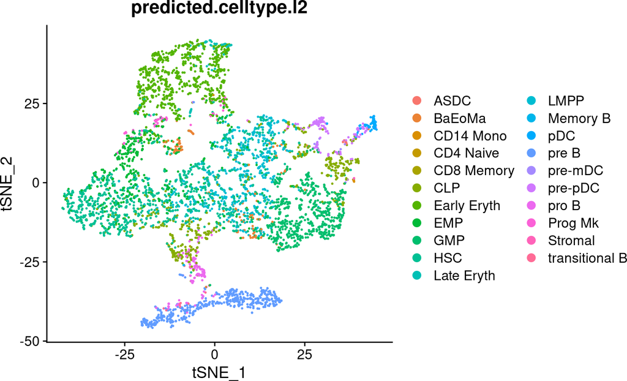

```r
DimPlot(setty_combined, reduction = "tsne",
        group.by = "predicted.celltype.l2")
```

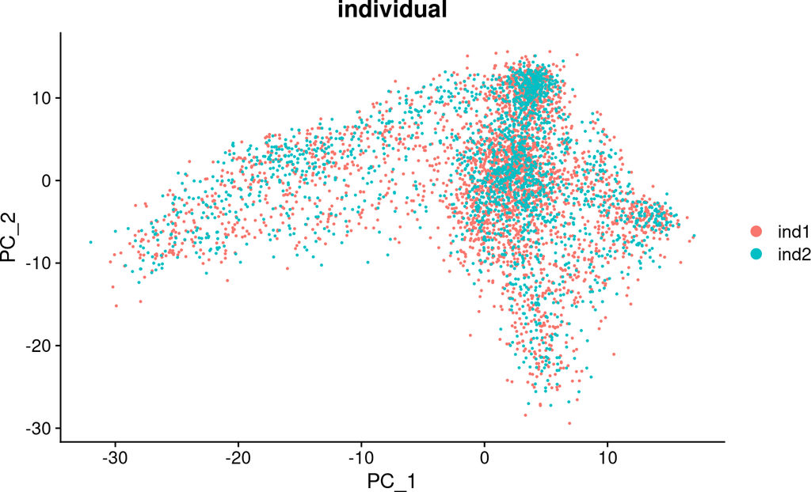

```r
DimPlot(setty_combined, reduction = "pca",
        group.by = "individual")
```

Observe how PCA does not separate cells by individual, which is an indicator of successful integration.

First, we need to transform this to a `SingleCellExperiment` object, which will then be converted to a `Milo` object, a related class used by the `miloR` package:

```r
# build SingleCellExperiment object
combined_sce <- as.SingleCellExperiment(setty_combined,
                                        assay = "integrated")
combined_sce <- runPCA(combined_sce)

# build Milo object
combined_milo <- Milo(combined_sce)

# remove SingleCellExperiment object to free memory
rm(setty_combined)
```

Next, we need to add the **KNN graph** to the Milo object. This is stored in the `graph` slot in the `Milo` object. The miloR package includes functionality to build and store the graph from the PCA dimensions stored in the `reducedDim` slot.

We will define two parameters: - `k`: the number of cell nearest-neighbours to use for KNN graph building - `d`: the number of reduced dimensions to use for KNN graph building

```r
combined_milo <- buildGraph(combined_milo, k = 50, d = 50)
```

```
## Constructing kNN graph with k:50
```

Now, we will define the neighbourhood of each cell, i.e. the index, which is dfined as the group of cells connected by an edge in the KNN graph to the index cell. We will set `k` and `d` to the same values as before, and `prop=0.2`, which corresponds to the proportion of cells to randomly sample to start the algorithm.

```r
combined_milo <- makeNhoods(combined_milo, prop = 0.2,
                            k = 50, d = 50, refined = FALSE)
```

```
## Checking valid object
```

Once we have defined neighbourhoods, it’s good to take a look at how big the neighbourhoods are (i.e. how many cells form each neighbourhood). This affects the power of DA testing. We can check this out using the plotNhoodSizeHist function. Empirically, we found it’s best to have a distribution peaking between 50 and 100. Otherwise you might consider rerunning makeNhoods increasing `k` and/or `prop`:

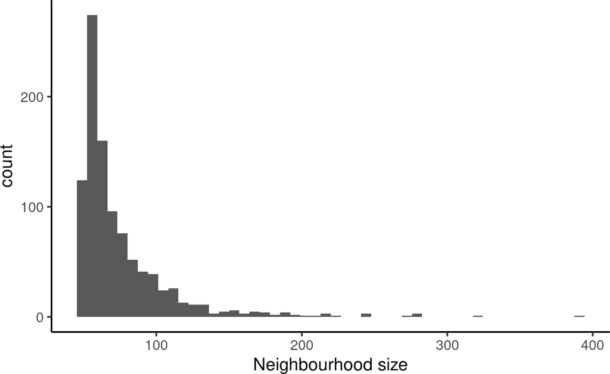

```r
plotNhoodSizeHist(combined_milo)
```

**NOTE:** for this tutorial, the `k` and `d` parameters have been adjusted to generate a distribution that satisifed this indicator. In a real-life scenario, we would need to adjust the parameters again to generate an adequate size of neighbourhoods for our data.

Now we have to count how many cells from each sample are in each neighbourhood. We need to use the cell metadata, contained in the `SingleCellExperiment` object, and specify which column contains the replicate (i.e. sample) information:

```r
combined_milo <- countCells(combined_milo,
                            meta.data = data.frame(colData(combined_sce)),
                            samples = "replicate")
```

```
## Checking meta.data validity
```

```
## Counting cells in neighbourhoods
```

This adds to the `Milo` object a `n \times m` matrix, where n is the number of neighbourhoods and m is the number of experimental samples (in our case, the replicates). Values indicate the number of cells from each sample counted in a neighbourhood. This count matrix will be used for DA testing.

```r
head(nhoodCounts(combined_milo))
```

```
## 6 x 4 sparse Matrix of class "dgCMatrix"
##   I1_rep1 I1_rep2 I2_rep1 I2_rep2
## 1      17      35      19      12
## 2       7      13      25      21
## 3       8      11      16      20
## 4      25      43      27      31
## 5      20      20      19      16
## 6       7      25      20      31
```

Now we are all set to test for differential abundance in neighbourhoods. `miloR` implement this hypothesis testing in a generalized linear model (GLM) framework, specifically using the Negative Binomial GLM implementation in `edgeR`.

We first need to think about our experimental design. The design matrix should match the replicates to a condition of interest, in this case, the donors defined in the `individual` column. As a result, we will compare DA across the two donors:

```r
design <- data.frame(replicate = colnames(nhoodCounts(combined_milo)),
                     individual = c("Ind1", "Ind1", "Ind2", "Ind2"))
rownames(design) <- design$replicate

design
```

```
##         replicate individual
## I1_rep1   I1_rep1       Ind1
## I1_rep2   I1_rep2       Ind1
## I2_rep1   I2_rep1       Ind2
## I2_rep2   I2_rep2       Ind2
```

Milo uses a type of False Discovery Rate (FDR) correction that accounts for the overlap between neighbourhoods, i.e. cells may belong to different neighbourhoods and therefore be tested multiple times during DA analysis. To use this correction, we first need to store the distances between nearest neighbors in the `Milo` object using the `calcNhoodDistance()` function:

```r
combined_milo <- calcNhoodDistance(combined_milo, d = 50)
```

```
## 'as(<dgTMatrix>, "dgCMatrix")' is deprecated.
## Use 'as(., "CsparseMatrix")' instead.
## See help("Deprecated") and help("Matrix-deprecated").
```

Since this can be memory intensive, we have stored a versino of the `Milo` object with pre-computed distances that you can load:

```r
combined_milo <- readRDS("../HandsOn4_CellType_Analysis/processed_data/combined_milo_NhoodDist.rds")
```

Then, we will do the test using the `testNhoods()` function and our experimental design matrix. This calculates a Fold-change and corrected P-value for each neighbourhood, which will indicate whether there is significant differential abundance between indidivuals.

```r
da_results <- testNhoods(combined_milo,
                         design = ~ individual,
                         design.df = design)
```

```
## Using TMM normalisation
```

```
## Performing spatial FDR correction withk-distance weighting
```

```r
head(da_results[order(da_results$SpatialFDR, decreasing = TRUE),])
```

```
##             logFC    logCPM            F    PValue       FDR Nhood SpatialFDR
## 572 -0.0003400364 10.156465 1.128031e-06 0.9993313 0.9993313   572  0.9993313
## 297  0.0011375817  9.619494 7.349687e-06 0.9978372 0.9992876   297  0.9993233
## 585  0.0009472535  9.621746 5.127577e-06 0.9981935 0.9992876   585  0.9993233
## 878  0.0008990144  9.622302 4.625107e-06 0.9982843 0.9992876   878  0.9993233
## 959  0.0011370592  9.619487 7.342223e-06 0.9978383 0.9992876   959  0.9993233
## 378 -0.0030706026  9.668259 5.871455e-05 0.9938870 0.9989991   378  0.9982944
```

Finally, to visualize the DA results, we build an abstracted graph of neighbourhoods that we can plot together with the single-cell reduced dimension plot:

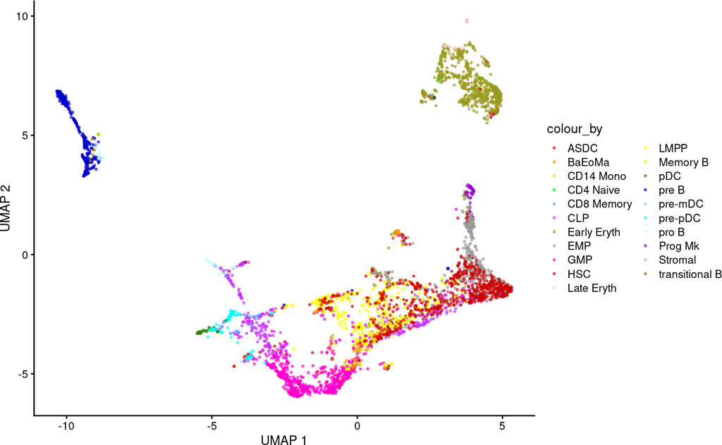

```r
combined_milo <- buildNhoodGraph(combined_milo)

combined_milo <- runUMAP(combined_milo)

# load palettes for visualization
library(paletteer)

plotUMAP(combined_milo, colour_by = "predicted.celltype.l2", point_size = 0.5) +
  scale_color_manual(values = paletteer_d("ggsci::default_ucscgb"))
```

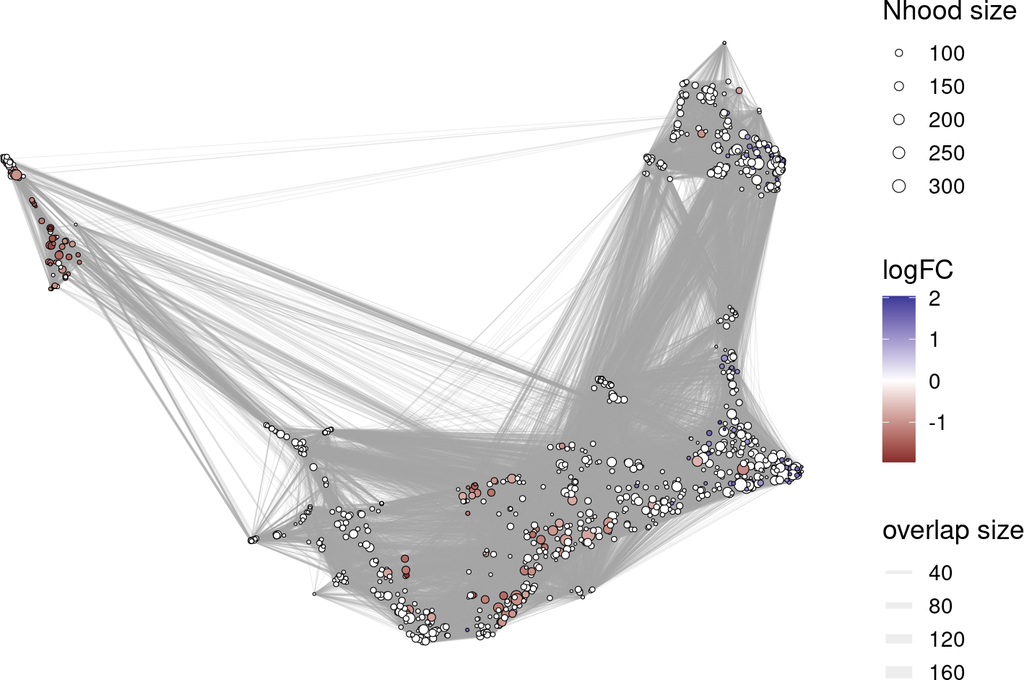

```r
plotNhoodGraphDA(combined_milo, da_results, alpha = 0.05)
```

Comparing these plots side by side, we observe that there are particularly large abundance changes in the area where pre-B cells accumulate, indicating that there are less B cells in individual 2 compared to individual 1. Similar patterns are observed in yellow-colored cells, which in this case correspond to Lympho-Myeloid Pirmed Progenitor (LMPP) cells. All in all, we may hypothesize that individual 1 has a larger amount of progenitors that differentiate into B/T lymphocytes than individual 2.